# M3: Time Series Decomposition Assignment

The data from 'ConstructionTimeSeriesDataV2.csv' is imported, which contains the Private and Public Construction costs by month given by the U.S. Census Bureau.

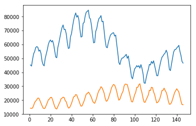

```python
import pandas as pd
import matplotlib.pyplot as plt
import numpy as np
from scipy import stats
%matplotlib inline

df = pd.read_csv('ConstructionTimeSeriesDataV2.csv')

plt.plot(df['Month'],df['Private Construction'])
plt.plot(df['Month'],df['Public Construction'])
```

```python
df.head()
```

|  | Month | Month-Year | Total Construction | Private Construction | Public Construction |
| --- | --- | --- | --- | --- | --- |
| 0 | 1 | Jan-02 | 59516 | 45273 | 14243 |
| 1 | 2 | Feb-02 | 58588 | 44475 | 14113 |
| 2 | 3 | Mar-02 | 63782 | 49396 | 14386 |
| 3 | 4 | Apr-02 | 69504 | 53283 | 16221 |
| 4 | 5 | May-02 | 73384 | 55009 | 18375 |

The next two cells compute data and graph showing the moving average of each point shown in blue and the original respective original data (private first and public second)

```
Average Squared Sale per Month:  37395667.05489795
            Month Month-Year  Total Construction  Private Construction  \
2003-07-31     19     Jul-03               82971                 62216
2003-08-31     20     Aug-03               85191                 63234
2003-09-30     21     Sep-03               83841                 61767
2003-10-31     22     Oct-03               83133                 62813
2003-11-30     23     Nov-03               77915                 60115
2003-12-31     24     Dec-03               71050                 55584
2004-01-31     25     Jan-04               64934                 50975
2004-02-29     26     Feb-04               64138                 50449
2004-03-31     27     Mar-04               73238                 57796
2004-04-30     28     Apr-04               78354                 61177
2004-05-31     29     May-04               83736                 65027
2004-06-30     30     Jun-04               89932                 69039
2004-07-31     31     Jul-04               93614                 72170
2004-08-31     32     Aug-04               96164                 74001
2004-09-30     33     Sep-04               92538                 70662
2004-10-31     34     Oct-04               90582                 70856
2004-11-30     35     Nov-04               86394                 67585
2004-12-31     36     Dec-04               77733                 61438
2005-01-31     37     Jan-05               71474                 57094
2005-02-28     38     Feb-05               72048                 57531
2005-03-31     39     Mar-05               81345                 65425
2005-04-30     40     Apr-05               85485                 67829
2005-05-31     41     May-05               92959                 72862
2005-06-30     42     Jun-05               99632                 77258
2005-07-31     43     Jul-05              103158                 80480
2005-08-31     44     Aug-05              106706                 82629
2005-09-30     45     Sep-05              103269                 79584
2005-10-31     46     Oct-05              102339                 80820
2005-11-30     47     Nov-05               97549                 77774
2005-12-31     48     Dec-05               88172                 70692
...           ...        ...                 ...                   ...
2010-03-31     99     Mar-10               60228                 39090
2010-04-30    100     Apr-10               66422                 42486
2010-05-31    101     May-10               68906                 43340
2010-06-30    102     Jun-10               74035                 44831
2010-07-31    103     Jul-10               73077                 43851
2010-08-31    104     Aug-10               75834                 44803
2010-09-30    105     Sep-10               74764                 42978
```

[output cut: 73 more lines]

```
2011-08-31                29297  44125.541667  1.355314e+07
2011-09-30                28990  44300.791667  4.331428e+06
2011-10-31                25957  44498.361111  1.419510e+07
2011-11-30                24014  44756.208333  1.504793e+03
2011-12-31                20828  45067.680556  1.334938e+07
2012-01-31                18059  45399.625000  6.066268e+07
2012-02-29                18483  45749.361111  6.808496e+07
2012-03-31                19491  46138.208333  2.336957e+07
2012-04-30                21259  46543.069444  2.493460e+06
2012-05-31                23898  46907.194444  2.058667e+06
2012-06-30                26975  47262.611111  1.323060e+07
2012-07-31                27104  47660.583333  1.708513e+07
2012-08-31                28640  48077.638889  2.495363e+07

[110 rows x 7 columns]
```

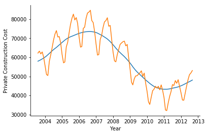

```python
def sqErr(row):
    return (row['Private Construction'] - row['MovAvg'])**2

df['MovAvg'] = np.NaN
df['sqErr'] = np.NaN
# Chaging the DataFrame index to DatetimeIndex data type is required for using one of the functions below
df.index = pd.DatetimeIndex(freq='m', start=pd.Timestamp(year=2002, month=1, day=31), periods = len(df['Private Construction']))
#print(len(data),'\n',data)

window = 36
window = window - window % 2
# Compute the moving average in the loop below using a window centered on the data point whose average is eing computed
for i in range(int(window/2),df.shape[0]-int(window/2)):
    df.loc[df.index[i],'MovAvg'] = (0.5*df.iloc[i - int(window/2)]['Private Construction'] + df.iloc[i - int(window/2)+1:i + int(window/2)]['Private Construction'].sum() + 0.5*df.iloc[i + int(window/2)]['Private Construction'])/float(window)

df['sqErr'] = (df['Private Construction'] - df['MovAvg'])**2
# The squared error can eb computed also with the dfHA.apply() method below
# Using dfHS.apply() in this case is unecessary complexity, but it is a good function to know about
#dfHS['sqErr'] = dfHS.apply(sqErr,axis='columns')

# The moving average cannot be applied to all rows and we need to delete those rows because we cannot use them in the analysis
df.dropna(how='any',inplace=True)

fig,ax = plt.subplots()
ax.plot(df['MovAvg'],label='Moving Avg.')
ax.plot(df['Private Construction'],label='Private Construction')
ax.set_xlabel('Year')
ax.set_ylabel('Private Construction Cost')
ax.spines['right'].set_visible(False)
ax.spines['top'].set_visible(False)
print('Average Squared Sale per Month: ',sum(df['sqErr'])/len(df))
print(df)
```

```
Average Squared Sale per Month:  14980631.752288744
            Month Month-Year  Total Construction  Private Construction  \
2003-07-31     37     Jan-05               71474                 57094
2003-08-31     38     Feb-05               72048                 57531
2003-09-30     39     Mar-05               81345                 65425
2003-10-31     40     Apr-05               85485                 67829
2003-11-30     41     May-05               92959                 72862
2003-12-31     42     Jun-05               99632                 77258
2004-01-31     43     Jul-05              103158                 80480
2004-02-29     44     Aug-05              106706                 82629
2004-03-31     45     Sep-05              103269                 79584
2004-04-30     46     Oct-05              102339                 80820
2004-05-31     47     Nov-05               97549                 77774
2004-06-30     48     Dec-05               88172                 70692
2004-07-31     49     Jan-06               81058                 65339
2004-08-31     50     Feb-06               81478                 65622
2004-09-30     51     Mar-06               92855                 75163
2004-10-31     52     Apr-06               95324                 75780
2004-11-30     53     May-06              102495                 80488
2004-12-31     54     Jun-06              107607                 83196
2005-01-31     55     Jul-06              108423                 83700
2005-02-28     56     Aug-06              110434                 84649
2005-03-31     57     Sep-06              104191                 79268
2005-04-30     58     Oct-06              101582                 78199
2005-05-31     59     Nov-06               95339                 73461
2005-06-30     60     Dec-06               86436                 66972
2005-07-31     61     Jan-07               79406                 61161
2005-08-31     62     Feb-07               79177                 61437
2005-09-30     63     Mar-07               88905                 69403
2005-10-31     64     Apr-07               93375                 71433
2005-11-30     65     May-07              100534                 75685
2005-12-31     66     Jun-07              105399                 78562
...           ...        ...                 ...                   ...
2007-03-31     81     Sep-08               96755                 66012
2007-04-30     82     Oct-08               95612                 66730
2007-05-31     83     Nov-08               86067                 59993
2007-06-30     84     Dec-08               76645                 53884
2007-07-31     85     Jan-09               66944                 46974
2007-08-31     86     Feb-09               66296                 45548
2007-09-30     87     Mar-09               71624                 48688
```

[output cut: 73 more lines]

```
2008-08-31                18724  25415.194444  4.477208e+07
2008-09-30                21138  25362.902778  1.784980e+07
2008-10-31                23936  25297.916667  1.854817e+06
2008-11-30                25567  25228.680556  1.144600e+05
2008-12-31                29204  25173.236111  1.624706e+07
2009-01-31                29226  25119.833333  1.686060e+07
2009-02-28                31031  25061.819444  3.563112e+07
2009-03-31                31786  24982.513889  4.628742e+07
2009-04-30                27931  24883.361111  9.288103e+06
2009-05-31                25215  24796.388889  1.752353e+05
2009-06-30                21274  24715.111111  1.184125e+07
2009-07-31                18578  24608.347222  3.636509e+07
2009-08-31                18475  24508.166667  3.639910e+07

[74 rows x 7 columns]
```

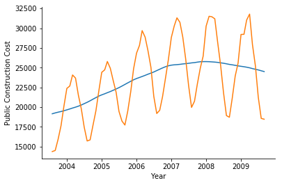

```python
def sqErr(row):
    return (row['Public Construction'] - row['MovAvg'])**2

df['MovAvg'] = np.NaN
df['sqErr'] = np.NaN
# Chaging the DataFrame index to DatetimeIndex data type is required for using one of the functions below
df.index = pd.DatetimeIndex(freq='m', start=pd.Timestamp(year=2002, month=1, day=31), periods = len(df['Public Construction']))
#print(len(data),'\n',data)

window = 36
window = window - window % 2
# Compute the moving average in the loop below using a window centered on the data point whose average is eing computed
for i in range(int(window/2),df.shape[0]-int(window/2)):
    df.loc[df.index[i],'MovAvg'] = (0.5*df.iloc[i - int(window/2)]['Public Construction'] + df.iloc[i - int(window/2)+1:i + int(window/2)]['Public Construction'].sum() + 0.5*df.iloc[i + int(window/2)]['Public Construction'])/float(window)

df['sqErr'] = (df['Public Construction'] - df['MovAvg'])**2
# The squared error can eb computed also with the dfHA.apply() method below
# Using dfHS.apply() in this case is unecessary complexity, but it is a good function to know about
#dfHS['sqErr'] = dfHS.apply(sqErr,axis='columns')

# The moving average cannot be applied to all rows and we need to delete those rows because we cannot use them in the analysis
df.dropna(how='any',inplace=True)

fig,ax = plt.subplots()
ax.plot(df['MovAvg'],label='Moving Avg.')
ax.plot(df['Public Construction'],label='Public Construction')
ax.set_xlabel('Year')
ax.set_ylabel('Public Construction Cost')
ax.spines['right'].set_visible(False)
ax.spines['top'].set_visible(False)
print('Average Squared Sale per Month: ',sum(df['sqErr'])/len(df))
print(df)
```

R1 is a computed by subtracting the moving average previously calculated from the time series data.

```python
df['R1Private'] = df['Private Construction'] - df['MovAvg']
df['R1ErrorPrivate'] = abs((df['Private Construction'] - df['R1Private'])/df['Private Construction'])
df.style.format({
    'MovAvg': '{:.1f}'.format,
    'sqErr': '{:,.1f}'.format,
    'R1Private': '{:,.1f}'.format,
    'R1ErrorPrivate': '{:,.3f}'.format
})
```

|  | Month | Month-Year | Total Construction | Private Construction | Public Construction | MovAvg | sqErr | R1Private | R1ErrorPrivate |
| --- | --- | --- | --- | --- | --- | --- | --- | --- | --- |
| 2003-07-31 00:00:00 | 37 | Jan-05 | 71474 | 57094 | 14380 | 19164.8 | 22,894,364.2 | 37,929.2 | 0.336 |
| 2003-08-31 00:00:00 | 38 | Feb-05 | 72048 | 57531 | 14517 | 19273.1 | 22,620,328.7 | 38,257.9 | 0.335 |
| 2003-09-30 00:00:00 | 39 | Mar-05 | 81345 | 65425 | 15920 | 19365.8 | 11,873,575.9 | 46,059.2 | 0.296 |
| 2003-10-31 00:00:00 | 40 | Apr-05 | 85485 | 67829 | 17656 | 19447.9 | 3,210,915.6 | 48,381.1 | 0.287 |
| 2003-11-30 00:00:00 | 41 | May-05 | 92959 | 72862 | 20097 | 19547.1 | 302,423.6 | 53,314.9 | 0.268 |
| 2003-12-31 00:00:00 | 42 | Jun-05 | 99632 | 77258 | 22375 | 19659.2 | 7,375,448.9 | 57,598.8 | 0.254 |
| 2004-01-31 00:00:00 | 43 | Jul-05 | 103158 | 80480 | 22679 | 19774.3 | 8,437,411.2 | 60,705.7 | 0.246 |
| 2004-02-29 00:00:00 | 44 | Aug-05 | 106706 | 82629 | 24078 | 19890.1 | 17,538,762.3 | 62,738.9 | 0.241 |
| 2004-03-31 00:00:00 | 45 | Sep-05 | 103269 | 79584 | 23685 | 20002.7 | 13,559,169.6 | 59,581.3 | 0.251 |
| 2004-04-30 00:00:00 | 46 | Oct-05 | 102339 | 80820 | 21519 | 20125.3 | 1,942,422.9 | 60,694.7 | 0.249 |
| 2004-05-31 00:00:00 | 47 | Nov-05 | 97549 | 77774 | 19775 | 20276.8 | 251,753.1 | 57,497.2 | 0.261 |
| 2004-06-30 00:00:00 | 48 | Dec-05 | 88172 | 70692 | 17479 | 20444.6 | 8,794,684.5 | 50,247.4 | 0.289 |
| 2004-07-31 00:00:00 | 49 | Jan-06 | 81058 | 65339 | 15719 | 20615.7 | 23,977,616.5 | 44,723.3 | 0.316 |
| 2004-08-31 00:00:00 | 50 | Feb-06 | 81478 | 65622 | 15857 | 20808.8 | 24,520,515.8 | 44,813.2 | 0.317 |
| 2004-09-30 00:00:00 | 51 | Mar-06 | 92855 | 75163 | 17692 | 21010.5 | 11,012,718.8 | 54,152.5 | 0.280 |
| 2004-10-31 00:00:00 | 52 | Apr-06 | 95324 | 75780 | 19544 | 21210.8 | 2,778,333.4 | 54,569.2 | 0.280 |
| 2004-11-30 00:00:00 | 53 | May-06 | 102495 | 80488 | 22007 | 21400.6 | 367,741.2 | 59,087.4 | 0.266 |
| 2004-12-31 00:00:00 | 54 | Jun-06 | 107607 | 83196 | 24411 | 21557.8 | 8,140,877.0 | 61,638.2 | 0.259 |
| 2005-01-31 00:00:00 | 55 | Jul-06 | 108423 | 83700 | 24723 | 21695.3 | 9,167,017.8 | 62,004.7 | 0.259 |
| 2005-02-28 00:00:00 | 56 | Aug-06 | 110434 | 84649 | 25785 | 21832.8 | 15,619,511.6 | 62,816.2 | 0.258 |
| 2005-03-31 00:00:00 | 57 | Sep-06 | 104191 | 79268 | 24923 | 21978.7 | 8,668,935.2 | 57,289.3 | 0.277 |
| 2005-04-30 00:00:00 | 58 | Oct-06 | 101582 | 78199 | 23384 | 22137.8 | 1,553,139.1 | 56,061.2 | 0.283 |
| 2005-05-31 00:00:00 | 59 | Nov-06 | 95339 | 73461 | 21878 | 22303.8 | 181,274.9 | 51,157.2 | 0.304 |
| 2005-06-30 00:00:00 | 60 | Dec-06 | 86436 | 66972 | 19464 | 22475.5 | 9,069,132.2 | 44,496.5 | 0.336 |
| 2005-07-31 00:00:00 | 61 | Jan-07 | 79406 | 61161 | 18245 | 22670.9 | 19,588,984.2 | 38,490.1 | 0.371 |
| 2005-08-31 00:00:00 | 62 | Feb-07 | 79177 | 61437 | 17740 | 22877.3 | 26,391,480.3 | 38,559.7 | 0.372 |
| 2005-09-30 00:00:00 | 63 | Mar-07 | 88905 | 69403 | 19503 | 23075.7 | 12,764,344.1 | 46,327.3 | 0.332 |
| 2005-10-31 00:00:00 | 64 | Apr-07 | 93375 | 71433 | 21942 | 23276.0 | 1,779,630.1 | 48,157.0 | 0.326 |
| 2005-11-30 00:00:00 | 65 | May-07 | 100534 | 75685 | 24849 | 23465.8 | 1,913,303.7 | 52,219.2 | 0.310 |
| 2005-12-31 00:00:00 | 66 | Jun-07 | 105399 | 78562 | 26837 | 23626.6 | 10,306,596.8 | 54,935.4 | 0.301 |
| 2006-01-31 00:00:00 | 67 | Jul-07 | 107090 | 79270 | 27820 | 23759.0 | 16,491,495.4 | 55,511.0 | 0.300 |
| 2006-02-28 00:00:00 | 68 | Aug-07 | 110430 | 80737 | 29693 | 23886.0 | 33,721,087.7 | 56,851.0 | 0.296 |
| 2006-03-31 00:00:00 | 69 | Sep-07 | 105150 | 76278 | 28871 | 24026.8 | 23,466,488.9 | 52,251.2 | 0.315 |
| 2006-04-30 00:00:00 | 70 | Oct-07 | 103847 | 76695 | 27152 | 24174.7 | 8,864,100.3 | 52,520.3 | 0.315 |
| 2006-05-31 00:00:00 | 71 | Nov-07 | 94822 | 69777 | 25045 | 24311.8 | 537,594.5 | 45,465.2 | 0.348 |
| 2006-06-30 00:00:00 | 72 | Dec-07 | 84218 | 62840 | 21377 | 24454.9 | 9,473,742.0 | 38,385.1 | 0.389 |
| 2006-07-31 00:00:00 | 73 | Jan-08 | 77349 | 58150 | 19199 | 24630.4 | 29,499,985.3 | 33,519.6 | 0.424 |
| 2006-08-31 00:00:00 | 74 | Feb-08 | 77227 | 57625 | 19602 | 24803.3 | 27,053,435.0 | 32,821.7 | 0.430 |
| 2006-09-30 00:00:00 | 75 | Mar-08 | 82779 | 61442 | 21336 | 24969.0 | 13,198,588.1 | 36,473.0 | 0.406 |
| 2006-10-31 00:00:00 | 76 | Apr-08 | 87743 | 64051 | 23692 | 25123.2 | 2,048,238.0 | 38,927.8 | 0.392 |
| 2006-11-30 00:00:00 | 77 | May-08 | 92781 | 66767 | 26014 | 25238.0 | 602,219.1 | 41,529.0 | 0.378 |
| 2006-12-31 00:00:00 | 78 | Jun-08 | 96338 | 67515 | 28823 | 25319.3 | 12,275,972.1 | 42,195.7 | 0.375 |
| 2007-01-31 00:00:00 | 79 | Jul-08 | 98483 | 68180 | 30303 | 25362.6 | 24,407,854.1 | 42,817.4 | 0.372 |
| 2007-02-28 00:00:00 | 80 | Aug-08 | 99786 | 68477 | 31309 | 25385.8 | 35,083,903.4 | 43,091.2 | 0.371 |
| 2007-03-31 00:00:00 | 81 | Sep-08 | 96755 | 66012 | 30743 | 25422.2 | 28,310,824.0 | 40,589.8 | 0.385 |
| 2007-04-30 00:00:00 | 82 | Oct-08 | 95612 | 66730 | 28883 | 25472.6 | 11,630,752.4 | 41,257.4 | 0.382 |
| 2007-05-31 00:00:00 | 83 | Nov-08 | 86067 | 59993 | 26073 | 25510.3 | 316,656.3 | 34,482.7 | 0.425 |
| 2007-06-30 00:00:00 | 84 | Dec-08 | 76645 | 53884 | 22761 | 25553.1 | 7,795,962.0 | 28,330.9 | 0.474 |
| 2007-07-31 00:00:00 | 85 | Jan-09 | 66944 | 46974 | 19971 | 25605.5 | 31,747,903.3 | 21,368.5 | 0.545 |
| 2007-08-31 00:00:00 | 86 | Feb-09 | 66296 | 45548 | 20748 | 25643.6 | 23,967,280.1 | 19,904.4 | 0.563 |
| 2007-09-30 00:00:00 | 87 | Mar-09 | 71624 | 48688 | 22936 | 25702.7 | 7,654,675.0 | 22,985.3 | 0.528 |
| 2007-10-31 00:00:00 | 88 | Apr-09 | 75187 | 50234 | 24953 | 25754.0 | 641,623.3 | 24,480.0 | 0.513 |
| 2007-11-30 00:00:00 | 89 | May-09 | 76808 | 50342 | 26466 | 25767.2 | 488,329.2 | 24,574.8 | 0.512 |
| 2007-12-31 00:00:00 | 90 | Jun-09 | 81429 | 51170 | 30259 | 25768.1 | 20,167,958.3 | 25,401.9 | 0.504 |
| 2008-01-31 00:00:00 | 91 | Jul-09 | 83379 | 51872 | 31507 | 25758.1 | 33,050,202.5 | 26,113.9 | 0.497 |
| 2008-02-29 00:00:00 | 92 | Aug-09 | 84368 | 52917 | 31450 | 25733.8 | 32,675,037.7 | 27,183.2 | 0.486 |
| 2008-03-31 00:00:00 | 93 | Sep-09 | 81213 | 50026 | 31188 | 25706.0 | 30,052,476.3 | 24,320.0 | 0.514 |
| 2008-04-30 00:00:00 | 94 | Oct-09 | 79949 | 51729 | 28220 | 25670.5 | 6,499,879.4 | 26,058.5 | 0.496 |
| 2008-05-31 00:00:00 | 95 | Nov-09 | 71906 | 46599 | 25308 | 25616.1 | 94,923.9 | 20,982.9 | 0.550 |
| 2008-06-30 00:00:00 | 96 | Dec-09 | 64098 | 42209 | 21889 | 25562.0 | 13,490,622.9 | 16,647.0 | 0.606 |
| 2008-07-31 00:00:00 | 97 | Jan-10 | 55586 | 36650 | 18936 | 25491.0 | 42,968,389.2 | 11,159.0 | 0.696 |
| 2008-08-31 00:00:00 | 98 | Feb-10 | 54019 | 35295 | 18724 | 25415.2 | 44,772,083.1 | 9,879.8 | 0.720 |
| 2008-09-30 00:00:00 | 99 | Mar-10 | 60228 | 39090 | 21138 | 25362.9 | 17,849,803.5 | 13,727.1 | 0.649 |
| 2008-10-31 00:00:00 | 100 | Apr-10 | 66422 | 42486 | 23936 | 25297.9 | 1,854,817.0 | 17,188.1 | 0.595 |
| 2008-11-30 00:00:00 | 101 | May-10 | 68906 | 43340 | 25567 | 25228.7 | 114,460.0 | 18,111.3 | 0.582 |
| 2008-12-31 00:00:00 | 102 | Jun-10 | 74035 | 44831 | 29204 | 25173.2 | 16,247,057.5 | 19,657.8 | 0.562 |
| 2009-01-31 00:00:00 | 103 | Jul-10 | 73077 | 43851 | 29226 | 25119.8 | 16,860,604.7 | 18,731.2 | 0.573 |
| 2009-02-28 00:00:00 | 104 | Aug-10 | 75834 | 44803 | 31031 | 25061.8 | 35,631,116.5 | 19,741.2 | 0.559 |
| 2009-03-31 00:00:00 | 105 | Sep-10 | 74764 | 42978 | 31786 | 24982.5 | 46,287,423.3 | 17,995.5 | 0.581 |
| 2009-04-30 00:00:00 | 106 | Oct-10 | 73470 | 45539 | 27931 | 24883.4 | 9,288,102.8 | 20,655.6 | 0.546 |
| 2009-05-31 00:00:00 | 107 | Nov-10 | 68019 | 42805 | 25215 | 24796.4 | 175,235.3 | 18,008.6 | 0.579 |
| 2009-06-30 00:00:00 | 108 | Dec-10 | 60202 | 38928 | 21274 | 24715.1 | 11,841,245.7 | 14,212.9 | 0.635 |
| 2009-07-31 00:00:00 | 109 | Jan-11 | 50955 | 32377 | 18578 | 24608.3 | 36,365,087.6 | 7,768.7 | 0.760 |
| 2009-08-31 00:00:00 | 110 | Feb-11 | 50544 | 32069 | 18475 | 24508.2 | 36,399,100.0 | 7,560.8 | 0.764 |

```python
df['R1Public'] = df['Public Construction'] - df['MovAvg']
df['R1ErrorPublic'] = abs((df['Public Construction'] - df['R1Public'])/df['Public Construction'])
df.style.format({
    'MovAvg': '{:.1f}'.format,
    'sqErr': '{:,.1f}'.format,
    'R1Public': '{:,.1f}'.format,
    'R1ErrorPublic': '{:,.3f}'.format
})
```

|  | Month | Month-Year | Total Construction | Private Construction | Public Construction | MovAvg | sqErr | R1Private | R1ErrorPrivate | R1Public | R1ErrorPublic |
| --- | --- | --- | --- | --- | --- | --- | --- | --- | --- | --- | --- |
| 2003-07-31 00:00:00 | 37 | Jan-05 | 71474 | 57094 | 14380 | 19164.8 | 22,894,364.2 | 37929.2 | 0.335671 | -4,784.8 | 1.333 |
| 2003-08-31 00:00:00 | 38 | Feb-05 | 72048 | 57531 | 14517 | 19273.1 | 22,620,328.7 | 38257.9 | 0.335003 | -4,756.1 | 1.328 |
| 2003-09-30 00:00:00 | 39 | Mar-05 | 81345 | 65425 | 15920 | 19365.8 | 11,873,575.9 | 46059.2 | 0.296 | -3,445.8 | 1.216 |
| 2003-10-31 00:00:00 | 40 | Apr-05 | 85485 | 67829 | 17656 | 19447.9 | 3,210,915.6 | 48381.1 | 0.28672 | -1,791.9 | 1.101 |
| 2003-11-30 00:00:00 | 41 | May-05 | 92959 | 72862 | 20097 | 19547.1 | 302,423.6 | 53314.9 | 0.268275 | 549.9 | 0.973 |
| 2003-12-31 00:00:00 | 42 | Jun-05 | 99632 | 77258 | 22375 | 19659.2 | 7,375,448.9 | 57598.8 | 0.254462 | 2,715.8 | 0.879 |
| 2004-01-31 00:00:00 | 43 | Jul-05 | 103158 | 80480 | 22679 | 19774.3 | 8,437,411.2 | 60705.7 | 0.245704 | 2,904.7 | 0.872 |
| 2004-02-29 00:00:00 | 44 | Aug-05 | 106706 | 82629 | 24078 | 19890.1 | 17,538,762.3 | 62738.9 | 0.240715 | 4,187.9 | 0.826 |
| 2004-03-31 00:00:00 | 45 | Sep-05 | 103269 | 79584 | 23685 | 20002.7 | 13,559,169.6 | 59581.3 | 0.251341 | 3,682.3 | 0.845 |
| 2004-04-30 00:00:00 | 46 | Oct-05 | 102339 | 80820 | 21519 | 20125.3 | 1,942,422.9 | 60694.7 | 0.249014 | 1,393.7 | 0.935 |
| 2004-05-31 00:00:00 | 47 | Nov-05 | 97549 | 77774 | 19775 | 20276.8 | 251,753.1 | 57497.2 | 0.260714 | -501.8 | 1.025 |
| 2004-06-30 00:00:00 | 48 | Dec-05 | 88172 | 70692 | 17479 | 20444.6 | 8,794,684.5 | 50247.4 | 0.289206 | -2,965.6 | 1.170 |
| 2004-07-31 00:00:00 | 49 | Jan-06 | 81058 | 65339 | 15719 | 20615.7 | 23,977,616.5 | 44723.3 | 0.315519 | -4,896.7 | 1.312 |
| 2004-08-31 00:00:00 | 50 | Feb-06 | 81478 | 65622 | 15857 | 20808.8 | 24,520,515.8 | 44813.2 | 0.317101 | -4,951.8 | 1.312 |
| 2004-09-30 00:00:00 | 51 | Mar-06 | 92855 | 75163 | 17692 | 21010.5 | 11,012,718.8 | 54152.5 | 0.279533 | -3,318.5 | 1.188 |
| 2004-10-31 00:00:00 | 52 | Apr-06 | 95324 | 75780 | 19544 | 21210.8 | 2,778,333.4 | 54569.2 | 0.2799 | -1,666.8 | 1.085 |
| 2004-11-30 00:00:00 | 53 | May-06 | 102495 | 80488 | 22007 | 21400.6 | 367,741.2 | 59087.4 | 0.265885 | 606.4 | 0.972 |
| 2004-12-31 00:00:00 | 54 | Jun-06 | 107607 | 83196 | 24411 | 21557.8 | 8,140,877.0 | 61638.2 | 0.25912 | 2,853.2 | 0.883 |
| 2005-01-31 00:00:00 | 55 | Jul-06 | 108423 | 83700 | 24723 | 21695.3 | 9,167,017.8 | 62004.7 | 0.259203 | 3,027.7 | 0.878 |
| 2005-02-28 00:00:00 | 56 | Aug-06 | 110434 | 84649 | 25785 | 21832.8 | 15,619,511.6 | 62816.2 | 0.257922 | 3,952.2 | 0.847 |
| 2005-03-31 00:00:00 | 57 | Sep-06 | 104191 | 79268 | 24923 | 21978.7 | 8,668,935.2 | 57289.3 | 0.277271 | 2,944.3 | 0.882 |
| 2005-04-30 00:00:00 | 58 | Oct-06 | 101582 | 78199 | 23384 | 22137.8 | 1,553,139.1 | 56061.2 | 0.283095 | 1,246.2 | 0.947 |
| 2005-05-31 00:00:00 | 59 | Nov-06 | 95339 | 73461 | 21878 | 22303.8 | 181,274.9 | 51157.2 | 0.303614 | -425.8 | 1.019 |
| 2005-06-30 00:00:00 | 60 | Dec-06 | 86436 | 66972 | 19464 | 22475.5 | 9,069,132.2 | 44496.5 | 0.335595 | -3,011.5 | 1.155 |
| 2005-07-31 00:00:00 | 61 | Jan-07 | 79406 | 61161 | 18245 | 22670.9 | 19,588,984.2 | 38490.1 | 0.370676 | -4,425.9 | 1.243 |
| 2005-08-31 00:00:00 | 62 | Feb-07 | 79177 | 61437 | 17740 | 22877.3 | 26,391,480.3 | 38559.7 | 0.372369 | -5,137.3 | 1.290 |
| 2005-09-30 00:00:00 | 63 | Mar-07 | 88905 | 69403 | 19503 | 23075.7 | 12,764,344.1 | 46327.3 | 0.332489 | -3,572.7 | 1.183 |
| 2005-10-31 00:00:00 | 64 | Apr-07 | 93375 | 71433 | 21942 | 23276.0 | 1,779,630.1 | 48157 | 0.325844 | -1,334.0 | 1.061 |
| 2005-11-30 00:00:00 | 65 | May-07 | 100534 | 75685 | 24849 | 23465.8 | 1,913,303.7 | 52219.2 | 0.310045 | 1,383.2 | 0.944 |
| 2005-12-31 00:00:00 | 66 | Jun-07 | 105399 | 78562 | 26837 | 23626.6 | 10,306,596.8 | 54935.4 | 0.300738 | 3,210.4 | 0.880 |
| 2006-01-31 00:00:00 | 67 | Jul-07 | 107090 | 79270 | 27820 | 23759.0 | 16,491,495.4 | 55511 | 0.299723 | 4,061.0 | 0.854 |
| 2006-02-28 00:00:00 | 68 | Aug-07 | 110430 | 80737 | 29693 | 23886.0 | 33,721,087.7 | 56851 | 0.29585 | 5,807.0 | 0.804 |
| 2006-03-31 00:00:00 | 69 | Sep-07 | 105150 | 76278 | 28871 | 24026.8 | 23,466,488.9 | 52251.2 | 0.31499 | 4,844.2 | 0.832 |
| 2006-04-30 00:00:00 | 70 | Oct-07 | 103847 | 76695 | 27152 | 24174.7 | 8,864,100.3 | 52520.3 | 0.315206 | 2,977.3 | 0.890 |
| 2006-05-31 00:00:00 | 71 | Nov-07 | 94822 | 69777 | 25045 | 24311.8 | 537,594.5 | 45465.2 | 0.348421 | 733.2 | 0.971 |
| 2006-06-30 00:00:00 | 72 | Dec-07 | 84218 | 62840 | 21377 | 24454.9 | 9,473,742.0 | 38385.1 | 0.389162 | -3,077.9 | 1.144 |
| 2006-07-31 00:00:00 | 73 | Jan-08 | 77349 | 58150 | 19199 | 24630.4 | 29,499,985.3 | 33519.6 | 0.423566 | -5,431.4 | 1.283 |
| 2006-08-31 00:00:00 | 74 | Feb-08 | 77227 | 57625 | 19602 | 24803.3 | 27,053,435.0 | 32821.7 | 0.430426 | -5,201.3 | 1.265 |
| 2006-09-30 00:00:00 | 75 | Mar-08 | 82779 | 61442 | 21336 | 24969.0 | 13,198,588.1 | 36473 | 0.406383 | -3,633.0 | 1.170 |
| 2006-10-31 00:00:00 | 76 | Apr-08 | 87743 | 64051 | 23692 | 25123.2 | 2,048,238.0 | 38927.8 | 0.392237 | -1,431.2 | 1.060 |
| 2006-11-30 00:00:00 | 77 | May-08 | 92781 | 66767 | 26014 | 25238.0 | 602,219.1 | 41529 | 0.378001 | 776.0 | 0.970 |
| 2006-12-31 00:00:00 | 78 | Jun-08 | 96338 | 67515 | 28823 | 25319.3 | 12,275,972.1 | 42195.7 | 0.375017 | 3,503.7 | 0.878 |
| 2007-01-31 00:00:00 | 79 | Jul-08 | 98483 | 68180 | 30303 | 25362.6 | 24,407,854.1 | 42817.4 | 0.371994 | 4,940.4 | 0.837 |
| 2007-02-28 00:00:00 | 80 | Aug-08 | 99786 | 68477 | 31309 | 25385.8 | 35,083,903.4 | 43091.2 | 0.370721 | 5,923.2 | 0.811 |
| 2007-03-31 00:00:00 | 81 | Sep-08 | 96755 | 66012 | 30743 | 25422.2 | 28,310,824.0 | 40589.8 | 0.385115 | 5,320.8 | 0.827 |
| 2007-04-30 00:00:00 | 82 | Oct-08 | 95612 | 66730 | 28883 | 25472.6 | 11,630,752.4 | 41257.4 | 0.381727 | 3,410.4 | 0.882 |
| 2007-05-31 00:00:00 | 83 | Nov-08 | 86067 | 59993 | 26073 | 25510.3 | 316,656.3 | 34482.7 | 0.425221 | 562.7 | 0.978 |
| 2007-06-30 00:00:00 | 84 | Dec-08 | 76645 | 53884 | 22761 | 25553.1 | 7,795,962.0 | 28330.9 | 0.474225 | -2,792.1 | 1.123 |
| 2007-07-31 00:00:00 | 85 | Jan-09 | 66944 | 46974 | 19971 | 25605.5 | 31,747,903.3 | 21368.5 | 0.5451 | -5,634.5 | 1.282 |
| 2007-08-31 00:00:00 | 86 | Feb-09 | 66296 | 45548 | 20748 | 25643.6 | 23,967,280.1 | 19904.4 | 0.563003 | -4,895.6 | 1.236 |
| 2007-09-30 00:00:00 | 87 | Mar-09 | 71624 | 48688 | 22936 | 25702.7 | 7,654,675.0 | 22985.3 | 0.527906 | -2,766.7 | 1.121 |
| 2007-10-31 00:00:00 | 88 | Apr-09 | 75187 | 50234 | 24953 | 25754.0 | 641,623.3 | 24480 | 0.512681 | -801.0 | 1.032 |
| 2007-11-30 00:00:00 | 89 | May-09 | 76808 | 50342 | 26466 | 25767.2 | 488,329.2 | 24574.8 | 0.511843 | 698.8 | 0.974 |
| 2007-12-31 00:00:00 | 90 | Jun-09 | 81429 | 51170 | 30259 | 25768.1 | 20,167,958.3 | 25401.9 | 0.503579 | 4,490.9 | 0.852 |
| 2008-01-31 00:00:00 | 91 | Jul-09 | 83379 | 51872 | 31507 | 25758.1 | 33,050,202.5 | 26113.9 | 0.49657 | 5,748.9 | 0.818 |
| 2008-02-29 00:00:00 | 92 | Aug-09 | 84368 | 52917 | 31450 | 25733.8 | 32,675,037.7 | 27183.2 | 0.486305 | 5,716.2 | 0.818 |
| 2008-03-31 00:00:00 | 93 | Sep-09 | 81213 | 50026 | 31188 | 25706.0 | 30,052,476.3 | 24320 | 0.513853 | 5,482.0 | 0.824 |
| 2008-04-30 00:00:00 | 94 | Oct-09 | 79949 | 51729 | 28220 | 25670.5 | 6,499,879.4 | 26058.5 | 0.49625 | 2,549.5 | 0.910 |
| 2008-05-31 00:00:00 | 95 | Nov-09 | 71906 | 46599 | 25308 | 25616.1 | 94,923.9 | 20982.9 | 0.549713 | -308.1 | 1.012 |
| 2008-06-30 00:00:00 | 96 | Dec-09 | 64098 | 42209 | 21889 | 25562.0 | 13,490,622.9 | 16647 | 0.605604 | -3,673.0 | 1.168 |
| 2008-07-31 00:00:00 | 97 | Jan-10 | 55586 | 36650 | 18936 | 25491.0 | 42,968,389.2 | 11159 | 0.695526 | -6,555.0 | 1.346 |
| 2008-08-31 00:00:00 | 98 | Feb-10 | 54019 | 35295 | 18724 | 25415.2 | 44,772,083.1 | 9879.81 | 0.720079 | -6,691.2 | 1.357 |
| 2008-09-30 00:00:00 | 99 | Mar-10 | 60228 | 39090 | 21138 | 25362.9 | 17,849,803.5 | 13727.1 | 0.648834 | -4,224.9 | 1.200 |
| 2008-10-31 00:00:00 | 100 | Apr-10 | 66422 | 42486 | 23936 | 25297.9 | 1,854,817.0 | 17188.1 | 0.595441 | -1,361.9 | 1.057 |
| 2008-11-30 00:00:00 | 101 | May-10 | 68906 | 43340 | 25567 | 25228.7 | 114,460.0 | 18111.3 | 0.582111 | 338.3 | 0.987 |
| 2008-12-31 00:00:00 | 102 | Jun-10 | 74035 | 44831 | 29204 | 25173.2 | 16,247,057.5 | 19657.8 | 0.561514 | 4,030.8 | 0.862 |
| 2009-01-31 00:00:00 | 103 | Jul-10 | 73077 | 43851 | 29226 | 25119.8 | 16,860,604.7 | 18731.2 | 0.572845 | 4,106.2 | 0.860 |
| 2009-02-28 00:00:00 | 104 | Aug-10 | 75834 | 44803 | 31031 | 25061.8 | 35,631,116.5 | 19741.2 | 0.559378 | 5,969.2 | 0.808 |
| 2009-03-31 00:00:00 | 105 | Sep-10 | 74764 | 42978 | 31786 | 24982.5 | 46,287,423.3 | 17995.5 | 0.581286 | 6,803.5 | 0.786 |
| 2009-04-30 00:00:00 | 106 | Oct-10 | 73470 | 45539 | 27931 | 24883.4 | 9,288,102.8 | 20655.6 | 0.546419 | 3,047.6 | 0.891 |
| 2009-05-31 00:00:00 | 107 | Nov-10 | 68019 | 42805 | 25215 | 24796.4 | 175,235.3 | 18008.6 | 0.579287 | 418.6 | 0.983 |
| 2009-06-30 00:00:00 | 108 | Dec-10 | 60202 | 38928 | 21274 | 24715.1 | 11,841,245.7 | 14212.9 | 0.634893 | -3,441.1 | 1.162 |
| 2009-07-31 00:00:00 | 109 | Jan-11 | 50955 | 32377 | 18578 | 24608.3 | 36,365,087.6 | 7768.65 | 0.760056 | -6,030.3 | 1.325 |
| 2009-08-31 00:00:00 | 110 | Feb-11 | 50544 | 32069 | 18475 | 24508.2 | 36,399,100.0 | 7560.83 | 0.764232 | -6,033.2 | 1.327 |

The two cells below, which creates a graph for both data sets, is a visualization of R1 decomposed and presents the average residual demand pattern.

```
Average Residual:  38053.268018018
```

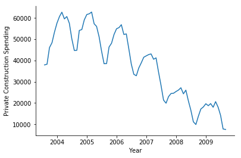

```python
fig,ax = plt.subplots()
ax.plot(df['R1Private'])
ax.set_xlabel('Year')
ax.set_ylabel('Private Construction Spending')
ax.spines['right'].set_visible(False)
ax.spines['top'].set_visible(False)
print('Average Residual: ', sum(df['R1Private'])/len(df))
```

```
Average Residual:  26.322072072071958
```

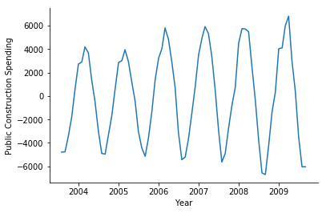

```python
fig,ax = plt.subplots()
ax.plot(df['R1Public'])
ax.set_xlabel('Year')
ax.set_ylabel('Public Construction Spending')
ax.spines['right'].set_visible(False)
ax.spines['top'].set_visible(False)
print('Average Residual: ', sum(df['R1Public'])/len(df))
```

Autocorrelation analysis will indicate whether there is any cyclical patterns in the data, which will be represented from the data below.

```python
maxCorr = 0.0
period = np.NaN
for i in range(1,37):
    corr = df['R1Private'].autocorr(lag=i)
    print('Correlation, lag ',i,'   ',corr)
    if corr > maxCorr:
        maxCorr = corr
        period = i
print('period = ',period,'     Maximum Correlation = ',maxCorr)
```

```
Correlation, lag  1     0.9718387266072528
Correlation, lag  2     0.9158609654408882
Correlation, lag  3     0.8458576640892178
Correlation, lag  4     0.7816612084991883
Correlation, lag  5     0.7338968283329242
Correlation, lag  6     0.7029340723634733
Correlation, lag  7     0.7088211390163105
Correlation, lag  8     0.7369520002928592
Correlation, lag  9     0.7842458587925888
Correlation, lag  10     0.8480957432031098
Correlation, lag  11     0.9024949519056955
Correlation, lag  12     0.9237033381184101
Correlation, lag  13     0.879546712616029
Correlation, lag  14     0.8002636771397148
Correlation, lag  15     0.7042141175155229
Correlation, lag  16     0.6101038328176431
Correlation, lag  17     0.5400094207350175
Correlation, lag  18     0.49139975630706206
Correlation, lag  19     0.4920957778304577
Correlation, lag  20     0.525025648037633
Correlation, lag  21     0.5854911679914513
Correlation, lag  22     0.6745941111159777
Correlation, lag  23     0.7564983817919559
Correlation, lag  24     0.7919973115202892
Correlation, lag  25     0.7295152229233156
Correlation, lag  26     0.6046954959335024
Correlation, lag  27     0.4431160798245856
Correlation, lag  28     0.2846779106029786
Correlation, lag  29     0.1673223039759231
Correlation, lag  30     0.07722306932914735
Correlation, lag  31     0.06404473355010634
Correlation, lag  32     0.10058934793268602
Correlation, lag  33     0.19431527712339292
Correlation, lag  34     0.35120407275574517
Correlation, lag  35     0.4940647077985893
Correlation, lag  36     0.5576262348722707
period =  1      Maximum Correlation =  0.9718387266072528
```

```python
maxCorr = 0.0
period = np.NaN
for i in range(1,37):
    corr = df['R1Public'].autocorr(lag=i)
    print('Correlation, lag ',i,'   ',corr)
    if corr > maxCorr:
        maxCorr = corr
        period = i
print('period = ',period,'     Maximum Correlation = ',maxCorr)
```

```
Correlation, lag  1     0.8542129071415239
Correlation, lag  2     0.483778620982585
Correlation, lag  3     -0.014002385567195744
Correlation, lag  4     -0.49819401930502843
Correlation, lag  5     -0.829508118249748
Correlation, lag  6     -0.9523747067186772
Correlation, lag  7     -0.8405728300831049
Correlation, lag  8     -0.5008033539105848
Correlation, lag  9     -0.003965801651178323
Correlation, lag  10     0.4813005165722554
Correlation, lag  11     0.8423140416589874
Correlation, lag  12     0.9831515976360988
Correlation, lag  13     0.8538494269790771
Correlation, lag  14     0.4926720370364964
Correlation, lag  15     -0.00853743257335958
Correlation, lag  16     -0.49556326137663687
Correlation, lag  17     -0.8297630324907732
Correlation, lag  18     -0.9531763107082359
Correlation, lag  19     -0.8427618336291858
Correlation, lag  20     -0.5016993047185025
Correlation, lag  21     -0.004620756735558917
Correlation, lag  22     0.48718348876780393
Correlation, lag  23     0.8476196784556941
Correlation, lag  24     0.9811025553495574
Correlation, lag  25     0.8476228377261206
Correlation, lag  26     0.4746269009819374
Correlation, lag  27     -0.028881646948205452
Correlation, lag  28     -0.5075116510296945
Correlation, lag  29     -0.8363503398691381
Correlation, lag  30     -0.9678706445861109
Correlation, lag  31     -0.8702255897002927
Correlation, lag  32     -0.5379374122572224
Correlation, lag  33     -0.03407278765095094
Correlation, lag  34     0.48214981131327495
Correlation, lag  35     0.8454133954797538
Correlation, lag  36     0.9824773751220638
period =  12      Maximum Correlation =  0.9831515976360988
```

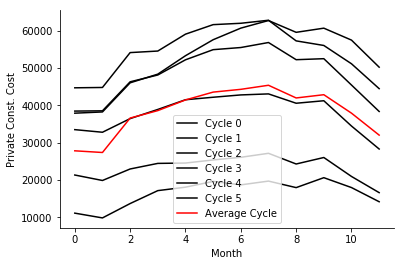

```python
period = 12
cycleLen = period
numCycles = int(len(df)/cycleLen + 0.5)
cycles = [df.iloc[range(i*period,min((i+1)*period,len(df)))]['R1Private'] for i in range(numCycles)]
ptsInCycles = [df.iloc[range(i,len(df['R1Private']),period)]['R1Private'].tolist() for i in range(period)]
avg = [sum(pts)/len(pts) for pts in ptsInCycles]

fig,ax = plt.subplots()
for i in range(len(cycles)):
    ax.plot(cycles[i].values,label='Cycle '+str(i),c='k')
ax.plot(avg,label='Average Cycle',c='r')
ax.set_xlabel('Month')
ax.set_ylabel('Private Const. Cost')
ax.spines['right'].set_visible(False)
ax.spines['top'].set_visible(False)
ax.legend()
```

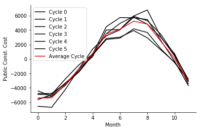

```python
period = 12
cycleLen = period
numCycles = int(len(df)/cycleLen + 0.5)
cycles = [df.iloc[range(i*period,min((i+1)*period,len(df)))]['R1Public'] for i in range(numCycles)]
ptsInCycles = [df.iloc[range(i,len(df['R1Public']),period)]['R1Public'].tolist() for i in range(period)]
avg = [sum(pts)/len(pts) for pts in ptsInCycles]

fig,ax = plt.subplots()
for i in range(len(cycles)):
    ax.plot(cycles[i].values,label='Cycle '+str(i),c='k')
ax.plot(avg,label='Average Cycle',c='r')
ax.set_xlabel('Month')
ax.set_ylabel('Public Const. Cost')
ax.spines['right'].set_visible(False)
ax.spines['top'].set_visible(False)
ax.legend()
```

The below graphs give us an output that indicates how well the cyclical component and R1(Private,Public) match.

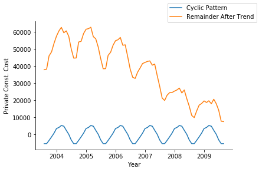

```python
cycleLen = period
numCycles = int(len(df)/cycleLen + 0.5)
df['C'] = np.NaN
for i in range(len(df)):
    df.loc[df.index[i], 'C'] = avg[i % cycleLen]

fig,ax = plt.subplots()
ax.plot(df['C'],label='Cyclic Pattern')
ax.plot(df['R1Private'],label='Remainder After Trend')
ax.set_xlabel('Year')
ax.set_ylabel('Private Const. Cost')
ax.spines['right'].set_visible(False)
ax.spines['top'].set_visible(False)
fig.legend()
```

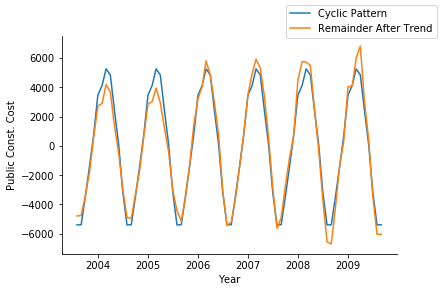

```python
cycleLen = period
numCycles = int(len(df)/cycleLen + 0.5)
df['C'] = np.NaN
for i in range(len(df)):
    df.loc[df.index[i], 'C'] = avg[i % cycleLen]

fig,ax = plt.subplots()
ax.plot(df['C'],label='Cyclic Pattern')
ax.plot(df['R1Public'],label='Remainder After Trend')
ax.set_xlabel('Year')
ax.set_ylabel('Public Const. Cost')
ax.spines['right'].set_visible(False)
ax.spines['top'].set_visible(False)
fig.legend()
```

```python
df['R2Private'] = df['R1Private'] - df['C']
df['R2ErrorPrivate'] = abs(df['R2Private']/df['Private Construction'])
df['fit'] = df['MovAvg'] + df['C']
df.drop(['sqErr'],axis=1,inplace=True)
print('Average Error: ', sum(df['R2ErrorPrivate'])/len(df))
print(df)
fig,ax = plt.subplots()
ax.plot(df['Private Construction'],label='Private Construction')
ax.plot(df['fit'], label = 'Fit')
ax.set_xlabel('Year')
ax.set_ylabel('Private Const. Cost')
ax.spines['right'].set_visible(False)
ax.spines['top'].set_visible(False)
fig.legend()
```

[output not shown]

```
Average Error:  0.023659063700256312
            Month Month-Year  Total Construction  Private Construction  \
2003-07-31     37     Jan-05               71474                 57094
2003-08-31     38     Feb-05               72048                 57531
2003-09-30     39     Mar-05               81345                 65425
2003-10-31     40     Apr-05               85485                 67829
2003-11-30     41     May-05               92959                 72862
2003-12-31     42     Jun-05               99632                 77258
2004-01-31     43     Jul-05              103158                 80480
2004-02-29     44     Aug-05              106706                 82629
2004-03-31     45     Sep-05              103269                 79584
2004-04-30     46     Oct-05              102339                 80820
2004-05-31     47     Nov-05               97549                 77774
2004-06-30     48     Dec-05               88172                 70692
2004-07-31     49     Jan-06               81058                 65339
2004-08-31     50     Feb-06               81478                 65622
2004-09-30     51     Mar-06               92855                 75163
2004-10-31     52     Apr-06               95324                 75780
2004-11-30     53     May-06              102495                 80488
2004-12-31     54     Jun-06              107607                 83196
2005-01-31     55     Jul-06              108423                 83700
2005-02-28     56     Aug-06              110434                 84649
2005-03-31     57     Sep-06              104191                 79268
2005-04-30     58     Oct-06              101582                 78199
2005-05-31     59     Nov-06               95339                 73461
2005-06-30     60     Dec-06               86436                 66972
2005-07-31     61     Jan-07               79406                 61161
2005-08-31     62     Feb-07               79177                 61437
2005-09-30     63     Mar-07               88905                 69403
2005-10-31     64     Apr-07               93375                 71433
2005-11-30     65     May-07              100534                 75685
2005-12-31     66     Jun-07              105399                 78562
...           ...        ...                 ...                   ...
2007-03-31     81     Sep-08               96755                 66012
2007-04-30     82     Oct-08               95612                 66730
2007-05-31     83     Nov-08               86067                 59993
2007-06-30     84     Dec-08               76645                 53884
2007-07-31     85     Jan-09               66944                 46974
2007-08-31     86     Feb-09               66296                 45548
2007-09-30     87     Mar-09               71624                 48688
```

[output cut: 199 more lines]

```
2008-08-31       0.069978  20034.271825
2008-09-30       0.034596  21869.291667
2008-10-31       0.001500  23900.106481
2008-11-30       0.015142  25954.134259
2008-12-31       0.019289  28640.692130
2009-01-31       0.000866  29251.321759
2009-02-28       0.022877  30321.090278
2009-03-31       0.061578  29828.696759
2009-04-30       0.021846  27320.817130
2009-05-31       0.013436  24876.210648
2009-06-30       0.013204  21554.907407
2009-07-31       0.034247  19214.242063
2009-08-31       0.035304  19127.244048

[74 rows x 14 columns]
```

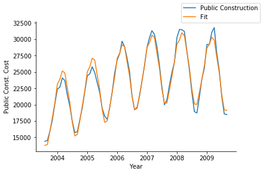

```python
df['R2Public'] = df['R1Public'] - df['C']
df['R2ErrorPublic'] = abs(df['R2Public']/df['Public Construction'])
df['fit'] = df['MovAvg'] + df['C']
df.drop(['sqErr'],axis=1,inplace=True)
print('Average Error: ', sum(df['R2ErrorPublic'])/len(df))
print(df)
fig,ax = plt.subplots()
ax.plot(df['Public Construction'],label='Public Construction')
ax.plot(df['fit'], label = 'Fit')
ax.set_xlabel('Year')
ax.set_ylabel('Public Const. Cost')
ax.spines['right'].set_visible(False)
ax.spines['top'].set_visible(False)
fig.legend()
```

```
Correlation, lag  1     0.9852110656940176
Correlation, lag  2     0.9697333843318826
Correlation, lag  3     0.9529678602988715
Correlation, lag  4     0.9398365108839041
Correlation, lag  5     0.9295149237932795
Correlation, lag  6     0.9149191023753861
Correlation, lag  7     0.9125329509752793
Correlation, lag  8     0.9057720865801664
Correlation, lag  9     0.9001045194986601
Correlation, lag  10     0.9048237996546019
Correlation, lag  11     0.9108812497651544
Correlation, lag  12     0.9158967825703211
Correlation, lag  13     0.8885943953293355
Correlation, lag  14     0.8614212261096534
Correlation, lag  15     0.8361200446884037
Correlation, lag  16     0.8141241324983032
Correlation, lag  17     0.7992858372159468
Correlation, lag  18     0.77983717890217
Correlation, lag  19     0.7750660577944878
Correlation, lag  20     0.7630110772902067
Correlation, lag  21     0.7510280561243045
Correlation, lag  22     0.7535442813731393
Correlation, lag  23     0.7605772118393468
Correlation, lag  24     0.7668610693644223
Correlation, lag  25     0.7237388622580708
Correlation, lag  26     0.6800644665944857
Correlation, lag  27     0.6307752403885408
Correlation, lag  28     0.5895769501418658
Correlation, lag  29     0.559484334068641
Correlation, lag  30     0.5083169658016087
Correlation, lag  31     0.4819160739397149
Correlation, lag  32     0.43171535930249194
Correlation, lag  33     0.3844351365544555
Correlation, lag  34     0.3751609006397428
Correlation, lag  35     0.37461014879826676
Correlation, lag  36     0.3725542024440974
period =  1      Maximum Correlation =  0.9852110656940176
```

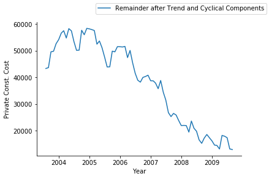

```python
fig,ax = plt.subplots()
ax.plot(df['R2Private'],label='Remainder after Trend and Cyclical Components')
ax.set_xlabel('Year')
ax.set_ylabel('Private Const. Cost')
ax.spines['right'].set_visible(False)
ax.spines['top'].set_visible(False)
fig.legend()
maxCorr = 0.0
period = np.NaN
for i in range(1,37):
    corr = df['R2Private'].autocorr(lag=i)
    print('Correlation, lag ',i,'   ',corr)
    if corr > maxCorr:
        maxCorr = corr
        period = i
print('period = ',period,'     Maximum Correlation = ',maxCorr)
```

```
Correlation, lag  1     0.7018060144309556
Correlation, lag  2     0.44417426491592876
Correlation, lag  3     0.24908249493681833
Correlation, lag  4     -0.02167396772443847
Correlation, lag  5     -0.1713704120071772
Correlation, lag  6     -0.27318292039099257
Correlation, lag  7     -0.3037012902222492
Correlation, lag  8     -0.21173118934335697
Correlation, lag  9     0.027358381937034788
Correlation, lag  10     0.14247350595654304
Correlation, lag  11     0.34796800540856343
Correlation, lag  12     0.4220959081055241
Correlation, lag  13     0.29313695492465563
Correlation, lag  14     0.27044274751032366
Correlation, lag  15     0.08658258660418262
Correlation, lag  16     -0.05145322646726127
Correlation, lag  17     -0.08574799967574044
Correlation, lag  18     -0.10534969727708256
Correlation, lag  19     -0.10983656108411723
Correlation, lag  20     -0.040363778661961815
Correlation, lag  21     0.014190554508501096
Correlation, lag  22     0.003988680978916471
Correlation, lag  23     0.06686646653399891
Correlation, lag  24     -0.133370036291196
Correlation, lag  25     -0.15743790755141765
Correlation, lag  26     -0.11954588682752573
Correlation, lag  27     -0.23954193235621082
Correlation, lag  28     -0.21103923423355717
Correlation, lag  29     -0.1397396364912848
Correlation, lag  30     -0.07370372205300574
Correlation, lag  31     -0.03363440807980038
Correlation, lag  32     -0.06232902239453509
Correlation, lag  33     -0.1943269591137645
Correlation, lag  34     -0.24615534817808069
Correlation, lag  35     -0.31744492839281024
Correlation, lag  36     -0.41767787719139304
period =  1      Maximum Correlation =  0.7018060144309556
```

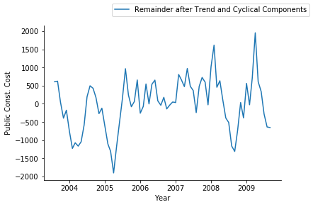

```python
fig,ax = plt.subplots()
ax.plot(df['R2Public'],label='Remainder after Trend and Cyclical Components')
ax.set_xlabel('Year')
ax.set_ylabel('Public Const. Cost')
ax.spines['right'].set_visible(False)
ax.spines['top'].set_visible(False)
fig.legend()
maxCorr = 0.0
period = np.NaN
for i in range(1,37):
    corr = df['R2Public'].autocorr(lag=i)
    print('Correlation, lag ',i,'   ',corr)
    if corr > maxCorr:
        maxCorr = corr
        period = i
print('period = ',period,'     Maximum Correlation = ',maxCorr)
```

The final graph below plots the model created versus the original data and R2 to estimate it's relativety to the original demand.

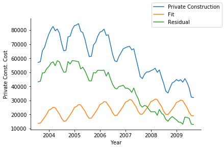

```python
fig,ax = plt.subplots()
ax.plot(df['Private Construction'],label='Private Construction')
ax.plot(df['fit'],label='Fit')
ax.plot(df['R2Private'],label='Residual')
ax.set_xlabel('Year')
ax.set_ylabel('Private Const. Cost')
ax.spines['right'].set_visible(False)
ax.spines['top'].set_visible(False)
fig.legend()
```

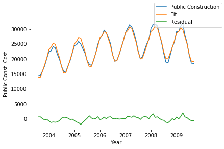

```python
fig,ax = plt.subplots()
ax.plot(df['Public Construction'],label='Public Construction')
ax.plot(df['fit'],label='Fit')
ax.plot(df['R2Public'],label='Residual')
ax.set_xlabel('Year')
ax.set_ylabel('Public Const. Cost')
ax.spines['right'].set_visible(False)
ax.spines['top'].set_visible(False)
fig.legend()
```